# practical_exercise_2, Methods 3, 2021, autumn semester

*It makes sense to include separate intercepts for the variables “subject” and “scenario”, since we then assume* *that each subject and scenario has different baselines - a different average effect in pitch per subject and* *scenario. By making separate intercepts, we account for individual differences across subject and scenario.*

4. describe the variance components of the second level (if any)  
   *This model has a sigma = 29.16333, an AIC = 2180.623, and a R2c = 0.8251343. The model has a slightly better AIC value than the other models, but a slightly worse sigma and R2c than model 5.*
5. include a Quantile-Quantile plot of your chosen model *When comparing a Q-Q-plot from model 6 and Q-Q-plot from model 5, the values seem to fit the line slightly better for model 6, but it is still has a right skewed tail. The residuals of the chosen model (m5) indicated minor violations from normality primarily at the right end of the line. Conceptually, model 6 might be justifiable, as one could argue that pitch would get affected depending on both gender and attitude (the interaction). However, as mentioned, the interaction was found to be insignificant and further theory would be needed to support this.*

I have chosen model m5.

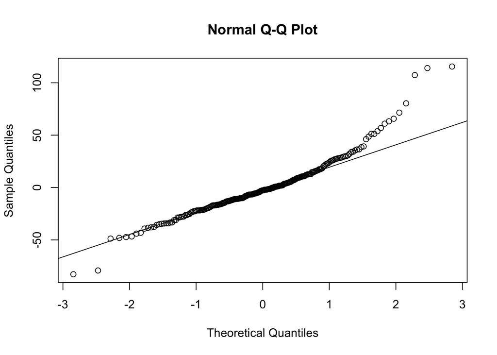

```r
qqnorm(residuals(m6))
qqline(residuals(m6))
```

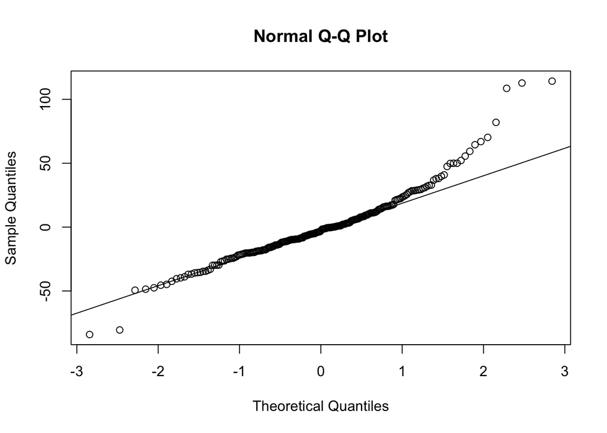

```r
# for comparison
qqnorm(resid(m5))
qqline(resid(m5))
```

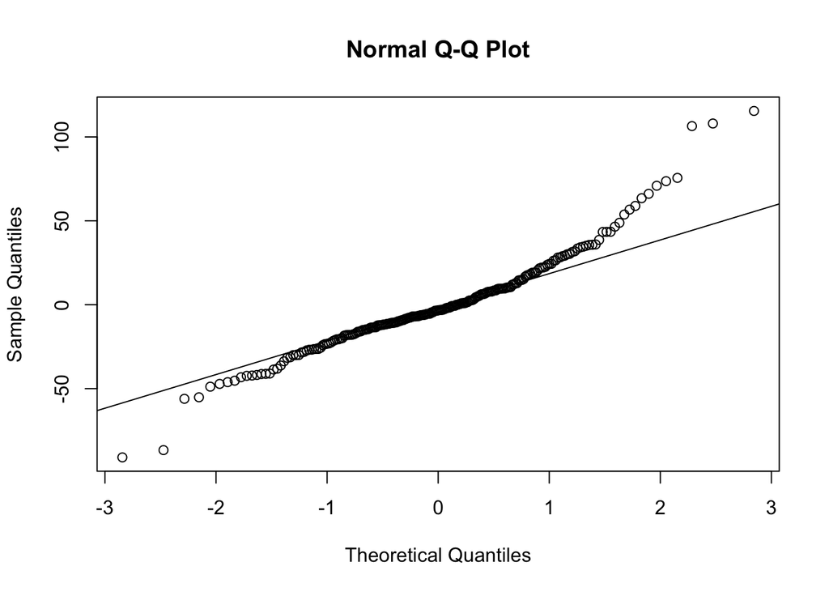

```r
qqnorm(resid(m4))
qqline(resid(m4))
```